# Statistical inference with the GSS data

## Setup

### Load packages

```r
library(ggplot2)
library(dplyr)
library(statsr)
```

### Load data

Make sure your data and R Markdown files are in the same directory. When loaded your data file will be called `gss`. Delete this note when before you submit your work.

```r
load("gss.Rdata")
```

## Part 1: Data

Sample: Data for this sample is gathered through personal interviews conducted on random members of the population. The data samples is from 1972 to 2012.

This data set can be used for inference, but cannot be used to make causal conclusions or for causality studies.

The target population of the GSS is people that live in households in the U.S. over the age of 18. The survey is conducted in English and started being conducted in Spanish in 2006. This survey only targets those that live households.

Conclusions can only be made for the target population.

## Part 2: Research question

**Research Quesiton:**

Is a connection between a person’s region of residence and chances of living in poverty at the age of 16?

As this survey covers 40 years of data and there have been many region changes in that time, a subset of time will need to be chosen to analyze. I decided to choose years greater than or equal to 2000, as this was a time relative economic prosperity for the U.S. and is more likely to point out the regions that are in trouble perpetually.

This question is of importance as it it shows which areas in the U.S. are in need of the most help, and where the system has failed. There are many negative effects to areas that have a high poverty level such as high crime and drugs.

Important varables to consider in asnwering this question are: region — Region of interview. year — GSS year for this respondent incom16 — Rs family income when 16 years old

```r
#set for consideration

r_i_study <- select(gss,year,region,incom16) %>% na.omit() %>%
  mutate(poverty=grepl("Far Below Average",incom16)) %>%
  mutate(y2000=as.factor(ifelse(year>=2000,"Y","N")))
```

## Part 3: Exploratory data analysis

Do start with I will output a table of all those that fit within the paramerters specified, since the start of the survey.

```r
poverty_by_region_table <- table(r_i_study$region,r_i_study$poverty)
addmargins(poverty_by_region_table)
```

```
##
##                   FALSE  TRUE   Sum
##   New England      1886   139  2025
##   Middle Atlantic  5953   497  6450
##   E. Nor. Central  7663   634  8297
##   W. Nor. Central  3063   231  3294
##   South Atlantic   7595   831  8426
##   E. Sou. Central  2555   303  2858
##   W. Sou. Central  3597   440  4037
##   Mountain         2371   167  2538
##   Pacific          5331   483  5814
##   Sum             40014  3725 43739
```

```r
prob_tab <- prop.table(poverty_by_region_table)
addmargins(prob_tab)
```

```
##
##                         FALSE        TRUE         Sum
##   New England     0.043119413 0.003177942 0.046297355
##   Middle Atlantic 0.136102792 0.011362857 0.147465649
##   E. Nor. Central 0.175198336 0.014495073 0.189693409
##   W. Nor. Central 0.070029036 0.005281328 0.075310364
##   South Atlantic  0.173643659 0.018999063 0.192642722
##   E. Sou. Central 0.058414687 0.006927456 0.065342143
##   W. Sou. Central 0.082237820 0.010059672 0.092297492
##   Mountain        0.054207915 0.003818103 0.058026018
##   Pacific         0.121882073 0.011042776 0.132924850
##   Sum             0.914835730 0.085164270 1.000000000
```

It’s easier to see visually in this bar graph.

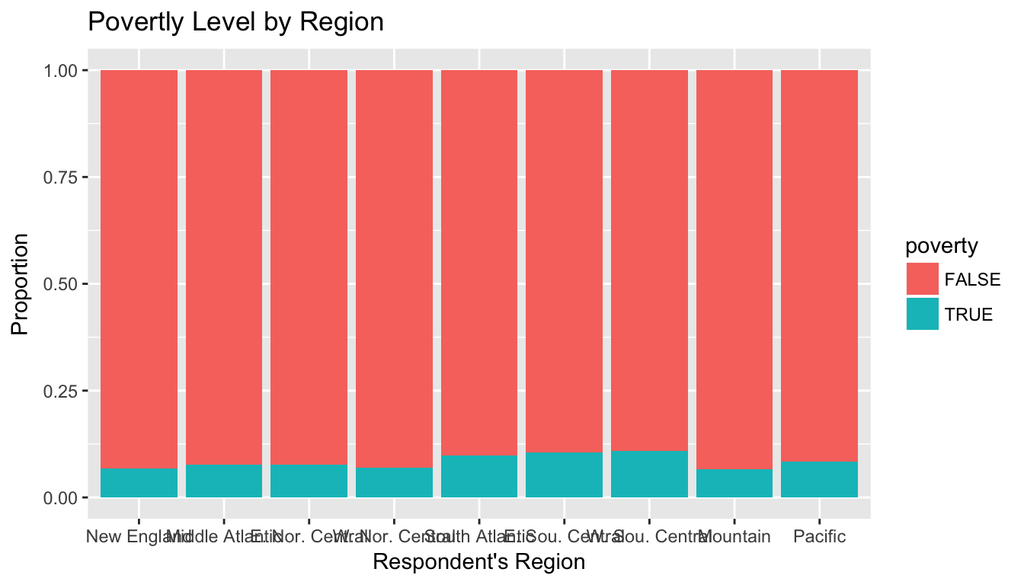

```r
ggplot(r_i_study) + aes(x=region,fill=poverty) + geom_bar(position = "fill") +
  labs(x="Respondent's Region",y="Proportion",title="Povertly Level by Region")
```

Next I will look at the data for the time period from 2000 to 2012. Which shows more modern data and distribution of poverty.

```r
recent_povert <- filter(r_i_study,y2000=="Y")
poverty_by_region_table <- table(recent_povert$region,recent_povert$poverty)
addmargins(poverty_by_region_table)
```

```
##
##                   FALSE  TRUE   Sum
##   New England       501    36   537
##   Middle Atlantic  1534   147  1681
##   E. Nor. Central  2099   158  2257
##   W. Nor. Central   804    84   888
##   South Atlantic   2474   314  2788
##   E. Sou. Central   693    82   775
##   W. Sou. Central  1212   191  1403
##   Mountain          894    84   978
##   Pacific          1672   203  1875
##   Sum             11883  1299 13182
```

```r
addmargins(prop.table(poverty_by_region_table))
```

```
##
##                         FALSE        TRUE         Sum
##   New England     0.038006372 0.002730997 0.040737369
##   Middle Atlantic 0.116370809 0.011151570 0.127522379
##   E. Nor. Central 0.159232286 0.011986042 0.171218328
##   W. Nor. Central 0.060992262 0.006372326 0.067364588
##   South Atlantic  0.187680170 0.023820361 0.211500531
##   E. Sou. Central 0.052571689 0.006220604 0.058792293
##   W. Sou. Central 0.091943559 0.014489455 0.106433015
##   Mountain        0.067819754 0.006372326 0.074192080
##   Pacific         0.126839630 0.015399788 0.142239417
##   Sum             0.901456532 0.098543468 1.000000000
```

## Part 4: Inference

**Hypothesis**

Null hypothesis: a respondents poverty level and region are independent variables. Alternative hypothesis: poverty level does indeed vary by region.

The variables being used for this questions are categorical. The method for testing that my hypothesis given that categorical variable is being used is the chi-squared test of independence.

In order to conduct a chi-squared test certain conditions must be met:

Sampled data must be independent. This is true based on the sampling methods. There needs to be a large enough sample size, which is true, as the sample size is in the thousands.

```r
chisq.test(r_i_study$region,r_i_study$poverty)
```

```
##
##  Pearson's Chi-squared test
##
## data:  r_i_study$region and r_i_study$poverty
## X-squared = 107.76, df = 8, p-value < 2.2e-16
```

```r
chisq.test(recent_povert$region,recent_povert$poverty)
```

```
##
##  Pearson's Chi-squared test
##
## data:  recent_povert$region and recent_povert$poverty
## X-squared = 61.942, df = 8, p-value = 1.936e-10
```

The test on the stat from 1972-2012 and the recent stat from 2000-2012 both produce p-values below alpha .05. This is reason to rejust the null hypothisis.

This means that poverty levels do indead vary by region.

Based on the results of this test further data could be gathered to determine why certain areas have greater poverty levels than others.